# Occupancy Model

### Occupancy model with covariates

Our next example uses simulated data. Here, we considers an occupancy model, with $T$ = 3 visits to each of $S$ = 100 different sites, looking for presence of a certain species.

There are also two covariates. Vegetation height at each site may affect the occupancy probability, and wind speed (which varies with each visit) may affect the detection probability.

### Occupancy model data

You can [download the simulated occupancy data here](https://danielturek.github.io/nimble-cefe-2019/data/occupancy_data.Rdata).

The simulated data for this example consists of:

- `vege`: A length $S$ = 100 vector with the vegetation cover at each site
- `wind`: A $S$ = 100 by $T$ = 3 matrix, giving the wind speed at each site, on each visit.
- `obs`: A $S$ = 100 by $T$ = 3 matrix, giving the observed occupancy (1), or absence (0) of the species, for each site and each visit.

### Exercise: Occupancy Model

We’ll construct and fit this occupancy model in NIMBLE.

Use latent states $z_i$ to represent the true occupancy of each site. We’ll use a static occupancy model, where we assume the true occupancy state is constant. That is, there’s no colonization or removals from sites, between sampling occasions.

Use $\phi_i$ to represent the probability of species presence, at each site. This may depend on the vegetation cover at each site (`vege[i]`). We’ll model $\phi_i$ on the logit scale, as:

$$\text{logit}(\phi_i) = \alpha_1 + \alpha_2 \cdot \text{vege}_i$$

Use $p_{i,j}$ to represent the probability of detection, at each site and each visit. This will depend on the wind speed on that visit (`wind[i, j]`). We’ll also model $p_{i,j}$ on the logit scale, as:

$$\text{logit}(p_{i,j}) = \beta_1 + \beta_2 \cdot \text{wind}_{i,j}$$

### Results and True Values

I ran this model for `niter = 20000` samples, and discarded the first `nburnin = 10000` samples as vurnin.

I got the following results:

```r
round(samplesSummary(samples), 2)
```

```
##           Mean Median St.Dev. 95%CI_low 95%CI_upp
## alpha[1]  0.23   0.10    0.73     -0.79      2.07
## alpha[2]  3.35   2.99    1.55      1.30      7.27
## beta[1]  -1.87  -1.86    0.39     -2.69     -1.14
## beta[2]  -3.13  -3.09    0.61     -4.45     -2.02
```

The true values that were used for generating the data were:

- $\alpha_1 = 0$
- $\alpha_2 = 3$
- $\beta_1 = -2$
- $\beta_2 = -3$

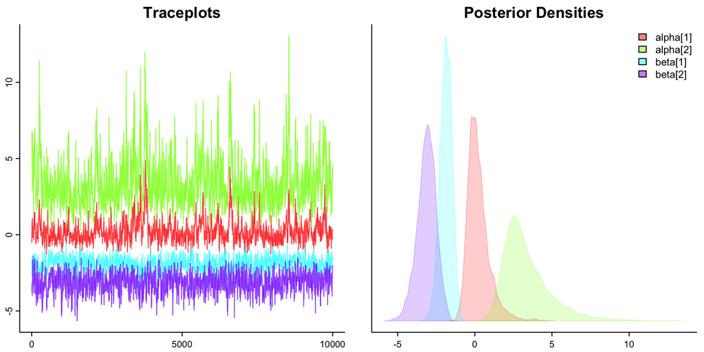

```r
basicMCMCplots::samplesPlot(samples)
```